```python
# imports
import numpy as np
import pandas as pd
import seaborn as sns
import matplotlib.pyplot as plt
from matplotlib.gridspec import GridSpec
```

```python
df = pd.read_csv("early_diabetes_data.csv")
```

# 1. Analysis Questions

The following questions are t to be explored in this data analysis:

- Which symptoms are most strongly associated with diabetes, and why might these relationships exist?
- How do different symptoms interact to influence diabetes risk?
- How does age influence the presence of diabetes, and does it change the importance of other symptoms?
- Are there distinct groups of patients based on symptoms, and do these groups differ in diabetes outcomes?
- Why do some individuals without key symptoms still get classified as diabetic?
- Can a small subset of symptoms explains most diabetes cases, and what does this suggest about early detection?

# 2. Dataset Description

The dataset used in this study consists of **520 patient records**, each observed on a set of physiological factors that is maybe associated with diabetes. The outcome variable, class, indicates whether a patient is categorized as Positive (early diabetic) or Negative (non-diabetic).

The dataset contains one continuous variable (Age) and 15 categorical predictor variables, each describing the presence or absence of a clinical condition or symptom. These variables include polyuria, polydipsia, sudden weight loss, weakness, polyphagia, partial paresis, and others that are known early clinical indicators of diabetes. Categorical variables are encoded using binary values (“Yes”/“No” or “Male”/“Female”).

The dataset was also collected from Syllhet Diabetes Hospital, Syllhet, Bangladesh

# 3. Data Wrangling

Since there were no missing values in the dataset, there was no data cleaning conducted. However, since the categorical variables were in string format, the values were encoded into 0s and 1s. Specifically, 1 for 'Female', 'Positive', or 'Yes'; and 0 for 'Male', 'Negative', or 'No'.

```python
df_factored = df.copy()

# flags for boolean indexing of columns
yn_flag = (df.columns != "Age") & (df.columns != "class") & (df.columns != "Gender")
pred_flag = df.columns != "class"

# Encoding Gender and class variables
df_factored["Gender"] = df["Gender"].map(lambda x: 1 if x == "Female" else 0)
df_factored["class"] = df["class"].map(lambda x: 1 if x == "Positive" else 0)

# encoding categorical variables(yes/no variables) in 0s and 1s
for col in df.columns[yn_flag]:
    df_factored[col] = df[col].map(lambda x: 1 if x == "Yes" else 0)

df_factored.head()
```

|  | Age | Gender | Polyuria | Polydipsia | sudden weight loss | weakness | Polyphagia | Genital thrush | visual blurring | Itching | Irritability | delayed healing | partial paresis | muscle stiffness | Alopecia | Obesity | class |
| --- | --- | --- | --- | --- | --- | --- | --- | --- | --- | --- | --- | --- | --- | --- | --- | --- | --- |
| 0 | 40 | 0 | 0 | 1 | 0 | 1 | 0 | 0 | 0 | 1 | 0 | 1 | 0 | 1 | 1 | 1 | 1 |
| 1 | 58 | 0 | 0 | 0 | 0 | 1 | 0 | 0 | 1 | 0 | 0 | 0 | 1 | 0 | 1 | 0 | 1 |
| 2 | 41 | 0 | 1 | 0 | 0 | 1 | 1 | 0 | 0 | 1 | 0 | 1 | 0 | 1 | 1 | 0 | 1 |
| 3 | 45 | 0 | 0 | 0 | 1 | 1 | 1 | 1 | 0 | 1 | 0 | 1 | 0 | 0 | 0 | 0 | 1 |
| 4 | 60 | 0 | 1 | 1 | 1 | 1 | 1 | 0 | 1 | 1 | 1 | 1 | 1 | 1 | 1 | 1 | 1 |

# 4. Exploratory Data Analysis

We can visually see from the distribution of the target classes the distribution is slightly imbalanced. It is supported by the percentage displayed above with 61.5% of the class consists of the positive class(early-diabetic) and 38.5% is of the negative class. However, since it hovers around the 60-40 split, this is approximately a fairly balanced dataset.

According to the age boxplot, early diabetic correspondents have a median age of 48 and a mean of 49.07 which indicates a right skewed distribution. Furthermore, the age range of early diabetics are 16-90. We also have observed some outliers specifically in early diabetic correspondents. Furthermore,we can also see that correspondents diagnosed with early diabetes tend to experience polyphagia, polyuria, polydipsia, partial paresis, and weakness. Particularly, the prevalence of the polyuria, polydipsia, and weakness was noticeably elevated.

## 4.1 Distribution of Target Class

From this graph, there is more Positive class than there is Negative class—i.e., there are more people that are diagnosed with Diabetes. Specifically, the proportion of the Positive and Negative class is 61.5% and 38.5% respectively.

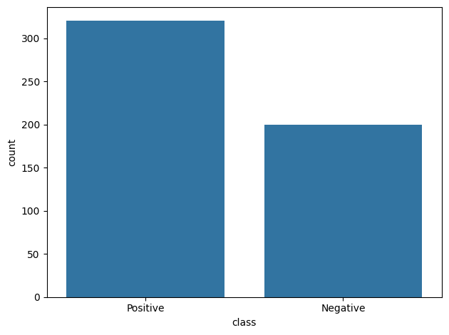

```python
sns.countplot(df, x='class')
plt.tight_layout()
plt.show()
```

```python
total = df.shape[0]
pos_rate = df[df['class'] == 'Positive'].shape[0]/(total)
neg_rate = df[df['class'] != 'Positive'].shape[0]/(total)

print(f"POSITIVE(%): {round(pos_rate,3)*100}%; NEGATIVE(%): {round(neg_rate,3)*100}%")
```

```
POSITIVE(%): 61.5%; NEGATIVE(%): 38.5%
```

## 4.2 Age Distribution

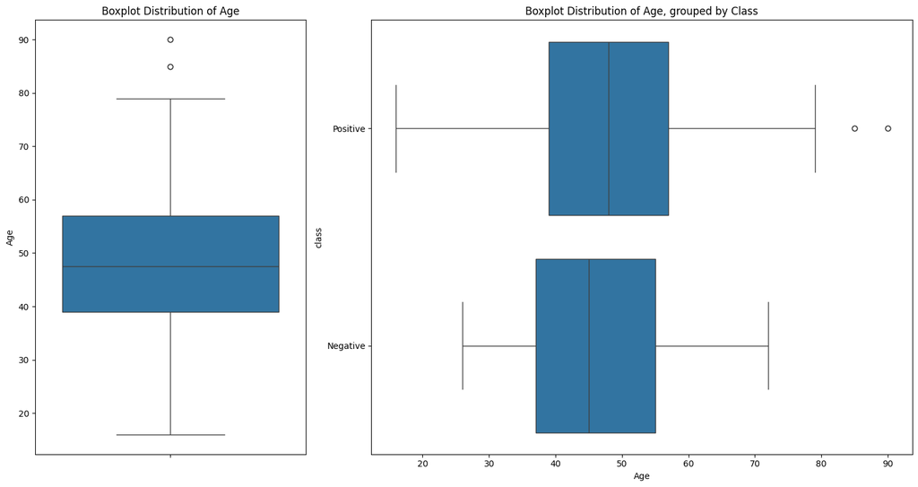

```python
fig = plt.figure(figsize=(15, 8))

gs = GridSpec(1, 2, width_ratios=[1, 2])

ax1 = fig.add_subplot(gs[0])
ax2 = fig.add_subplot(gs[1])

sns.boxplot(data=df, y='Age', orient='v', ax=ax1)
ax1.set_title("Boxplot Distribution of Age")

sns.boxplot(data=df, y='class', x='Age', orient='h', ax=ax2)
ax2.set_title("Boxplot Distribution of Age, grouped by Class")

plt.tight_layout()
```

```python
positive = df[df['class'] == 'Positive']

q1, q2, q3 = np.percentile(positive['Age'], [25, 50, 75])
IQR = q3-q1
upper_bound = q3 + IQR*1.5
lower_bound = q1 - IQR*1.5
outliers = positive[positive['Age'] > upper_bound]

pre_d_mean_age = positive['Age'].mean().round(2)
pre_d_median_age = positive['Age'].median().round(2)
pre_d_max_age = positive['Age'].max().round(2)
pre_d_min_age = positive['Age'].min().round(2)

print(f"early-diabetic:\n"
      f"\t\t25th percentile: {q1};\n"
      f"\t\t50th percentile: {q2};\n"
      f"\t\t75th percentile: {q3};\n"
      f"\t\tMean: {round(np.mean(positive['Age']),2)};\n"
      f"\t\tRange: [{pre_d_min_age},{pre_d_max_age}] \n"
      f"\t\tOutliers: {len(outliers)}\n")

negative = df[df['class'] == 'Negative']

q1, q2, q3 = np.percentile(negative['Age'], [25, 50, 75])
IQR = q3-q1
upper_bound = q3 + IQR*1.5
lower_bound = q1 - IQR*1.5
outliers = negative[negative['Age'] > upper_bound]

non_pre_d_mean_age = negative['Age'].mean().round(2)
non_pre_d_median_age = negative['Age'].median().round(2)
non_pre_d_max_age = negative['Age'].max().round(2)
non_pre_d_min_age = negative['Age'].min().round(2)

print(f"non-diabetic:\n"
      f"\t\t25th percentile: {q1};\n"
      f"\t\t50th percentile: {q2};\n"
      f"\t\t75th percentile: {q3};\n"
      f"\t\tMean: {round(np.mean(negative['Age']),2)};\n"
      f"\t\tRange: [{non_pre_d_min_age},{non_pre_d_max_age}] \n"
      f"\t\tOutliers: {len(outliers)}\n")
```

```
early-diabetic:
		25th percentile: 39.0;
		50th percentile: 48.0;
		75th percentile: 57.0;
		Mean: 49.07;
		Range: [16,90]
		Outliers: 4

non-diabetic:
		25th percentile: 37.0;
		50th percentile: 45.0;
		75th percentile: 55.0;
		Mean: 46.36;
		Range: [26,72]
		Outliers: 0
```

## 4.3 Categorical Variables

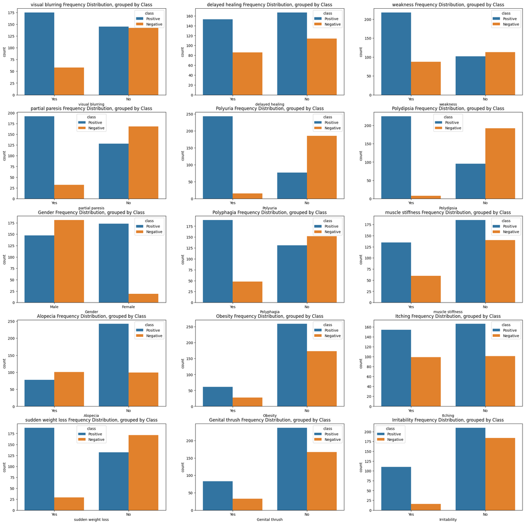

```python
pred_var = set(df.columns[(df.columns != 'class')])
cat_var = list(pred_var & set(df.columns[(df.columns != 'Age')]))

fig, axs = plt.subplots(5,3, figsize = (25,25))

for ax, col in zip(axs.flatten(), cat_var):
    if col == 'Gender':
        sns.countplot(data=df, x=col, hue='class', ax=ax, order=['Male', 'Female'])
    else:
        sns.countplot(data=df, x=col, hue='class', ax=ax, order=['Yes', 'No'])
    ax.set_title(f"{col} Frequency Distribution, grouped by Class")
```